# 10. 词嵌入

Natural Language Processing I

10. 词嵌入

WU Xiaokun 吴晓堃

xkun.wu [at] gmail

2022/04/22

## “喵说喵要喵”

> **เสด็จ**ให้มาทูลถาม**เสด็จ**ว่า จะ**เสด็จ**หรือไม่**เสด็จ** ถ้า**เสด็จ**จะ**เสด็จ** **เสด็จ**จะ**เสด็จ**ด้วย  
> –《四朝代》
- 泰语：针对皇室成员的称谓、动作情态和事物需要使用特殊的“皇语”

> **皇后娘娘**遣（我）来请示**公主殿下**，**公主殿下**是否**去**（大殿听经），如果**公主殿下**打算**去**（听经），**皇后娘娘**也一同**去**（听经）。

如果用“喵”字来替代这个词的话……

> **喵**让我来问**喵**，**喵**要**喵**吗？如果**喵**要**喵**的话，**喵**也**喵**。  
> **喵**说**喵**要**喵**。如果**喵**也**喵**，**喵**会很高兴。

# Word2vec

## 稀疏表示与信息压缩

TF-IDF和PPMI模型：**稀疏**向量、**矩阵**存储

- 元素：计数或计数的函数，大部分是0，**无有效信息**
  - 0值表示**不相关**，即同时出现的可能性为0
- 长向量：维数是语料集中的词汇数$|V|$，或文档数
  - 《现代汉语常用词表》2015年版：$56008$个词语

长向量导致超大矩阵：计算复杂度$O(|V|^2)$平方级增长

- **稀疏表示**：链表的变种，利用稀疏性
- 将信息压缩成稠密（的向量）表示
  - 称为**词嵌入 embedding**

## 词嵌入

词嵌入（向量）的元素：实数值

- 信息压缩通常导致**信息丢失**：$f: x \mapsto v$
  - 类比JPEG2000（小波变换）：切除高频信号，故多次保存后更模糊
- 缺点：很难对维度做出解释
  - 压缩相当于**编码**过程：词义随之消除
  - 例如 Morse 密码：4个“`H: ....`”可以压缩成“`16.`”
    - 但这无法从代码表找到解释
- 对比词向量：特征维度有明确（以文档/词度量的）词义

## 词嵌入的优点

在所有NLP任务中都比稀疏表示的效能好（原因尚在研究）

- 短向量 = 特征少：**参数少**，易于训练
  - 参数空间小：过拟合问题相对轻，泛化性好
- **低维度量**更有效：避免“维数灾难”，更容易发现词义相似的词
  - 例如：稀疏表示中`car`和`automobile`的维数差异大
    - $\Rightarrow$ 词义完全无关，与经验不符

## 常用词嵌入方法

**静态嵌入**：只计算一次词汇的固定嵌入表示

- NLP 启发的模型
  - word2vec (skipgram, CBOW), GloVe
- 矩阵分析、计算：如SVD
  - Latent Semantic Analysis (LSA)

**动态嵌入**：上下文不同，嵌入也不同

- ELMo、BERT

## 可在线下载的静态嵌入

[Mikolov 2013] word2vec

- https://code.google.com/archive/p/word2vec/
- 非常流行，训练速度快

[Pennington 2014] GloVe

- http://nlp.stanford.edu/projects/glove/

## word2vec：原理

**预测**，而不是计数

- 训练一个分类器：“食堂”在“下课”的上下文出现的**可能性**是多少？
- 对比之前：出现的次数是多少？简单假定统计词频为可能性

但是，我们并不关心分类的结果

- 将分类器**学到的权重**作为词嵌入，即当作**编码器**

## 自监督

词嵌入对机器学习的变革性贡献

- 文本的序列关系：天然可以作为训练数据的监督标注
  - 上下文可以看成**隐式标签**

$$他下课后去了食堂\\
他下课后去了 \square \square\\$$

这在机器学习分类中称为**自监督 self-supervision 学习**

- 避免了人工标定监督关系的步骤
- [Bengio 2003, Collobert 2011] 使用文本序列本身学习词嵌入

## word2vec 是简化方案

word2vec 比基于神经网络的语言模型简单得多

- 任务简化：转化成**二分类问题**
  - 只需预测词出现的可能性，而非预测选择哪个词
- 架构简化：只需逻辑回归分类器，而非复杂神经网络模型

我们主要讨论word2vec其中的一个版本

- [Mikolov 2013] **skip-gram with negative sampling (SGNS)**
  - skip-gram也称**跳元模型**

## skip-gram：工作流程

为了预测词$c$是目标词$w$的上下文

1. 将词对$(w,c)$看成一个**正例**
2. 随机采样词$w'$，并将词对$(w',c)$看成一个**负例**
3. 使用逻辑回归训练一个**分类器**
4. 将分类器学到的**权重**用作词嵌入

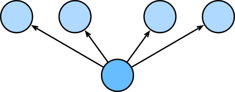

## skip-gram：示例

考虑如下文本：假定使用大小为$\pm 2$的上下文窗口

| 如 | [$\textcolor{orange}{\textbf{今}}$ | $\textcolor{orange}{\textbf{人}}$ | $\textcolor{red}{\textbf{方}}$ | $\textcolor{orange}{\textbf{为}}$ | $\textcolor{orange}{\textbf{刀}}$] | 俎 |
| --- | --- | --- | --- | --- | --- | --- |
|  | $c_1$ | $c_2$ | $\textcolor{red}{\textbf{w}}$ | $c_3$ | $c_4$ |  |

分类任务的构造：$P(+|w,c)$

- 词对：$(方,今)$，$(方,俎)$，$(方,鱼)$
- $P(-|w,c) = 1 - P(+|w,c)$

## skip-gram：原理

基于**相似度**的概率值

- 嵌入向量的相似度高：词对共同出现的可能性高
- 向量相似：内积数值大
  - 余弦值是**规范化**内积：取值$[-1,1]$

因此：$P(+|w,c) \propto \mathbf{c} \cdot \mathbf{w}$

- 但是，转化成概率值需要**归一化**
  - 余弦值也不是概率：如何将数值挤压到$[0,1]$？

## skip-gram：概率构造

回忆：**S形曲线**恰好有将数值挤压到$[0,1]$的性质

$$\sigma(x) = \frac{1}{1+\exp(-x)}$$

挤压相似度数值：

$$\begin{aligned}
P(+|w,c) &= \sigma(\mathbf{c} \cdot \mathbf{w}) = \frac{1}{1+\exp(-\mathbf{c} \cdot \mathbf{w})}\\
P(-|w,c) &= 1 - P(+|w,c) = \frac{1}{1+\exp(\mathbf{c} \cdot \mathbf{w})}\\
\end{aligned}$$

## skip-gram：多个上下文

skip-gram 假设所有上下文词是**相互独立**的

$$\begin{aligned}
P(+|w,c_{1:L}) &= \prod_i \sigma(\mathbf{c}_i \cdot \mathbf{w})\\
\end{aligned}$$

- 这些词的解耦合可以由**分词预处理**来保证

> 他 下课后 去了 食堂
- 取对数：避免多个小数相乘

$$\begin{aligned}
\log P(+|w,c_{1:L}) &= \sum_i \log \sigma(\mathbf{c}_i \cdot \mathbf{w})\\
\end{aligned}$$

## skip-gram：小结

skip-gram 构造了一个概率二分类器

- 输入：目标词$\mathbf{w}$，上下文$c_{1:L}$

$\mathbf{w}$在上下文窗口的概率：由向量相似度估计

- 基于假设：相关联的词出现在相同上下文
- 计算前提：需要所有词的嵌入向量

那么，如何学到这些词嵌入？

## 词嵌入集合

词嵌入的列表：即分类器的**参数集合**

- $f: x \mapsto v$

skip-gram 对每个词存储**两个词嵌入**

- 同一个词、两种表示
  - 分别用作目标、上下文

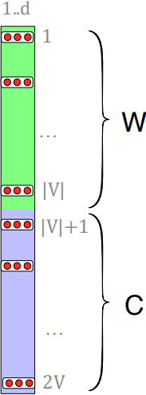

下面讨论如何学到这些词嵌入（训练分类器的真正目的）

# Word2vec：学习词嵌入

## skip-gram：负例

| 如 | [$\textcolor{orange}{\textbf{今}}$ | $\textcolor{orange}{\textbf{人}}$ | $\textcolor{red}{\textbf{方}}$ | $\textcolor{orange}{\textbf{为}}$ | $\textcolor{orange}{\textbf{刀}}$] | 俎 |
| --- | --- | --- | --- | --- | --- | --- |
|  | $c_1$ | $c_2$ | $\textcolor{red}{\textbf{w}}$ | $c_3$ | $c_4$ |  |

- 对**每个**正例：根据词频采样$k$个负例

正例 +

| $w$ | $c_{pos}$ |
| --- | --- |
| 方 | 今 |
| 方 | 人 |
| 方 | 为 |
| 方 | 刀 |

负例 -：$k = 2$

| $w$ | $c_{neg}$ |  | $w$ | $c_{neg}$ |
| --- | --- | --- | --- | --- |
| 方 | 鱼 |  | 方 | 俎 |
| 方 | 攻 |  | 方 | 仁 |
| 方 | 饥 |  | 方 | 商 |
| 方 | 美 |  | 方 | 谋 |

- 这也是名称的来历：**Skip-Gram with Negative Sampling (SGNS)**

## skip-gram：学习目标

初始状态：随机嵌入向量

学习过程逐渐达成**两个目标**，即目标损失函数的依据

- 最大化正例词对的相似度
- 最小化负例词对的相似度

## skip-gram：训练模型

损失函数

$$\begin{aligned}
L_{CE} &= -\log \left[ P(+|w, c_{pos}) \prod_{i=1}^k P(−|w, c_{neg}^i) \right]\\
&= - \left[ \log P(+|w, c_{pos}) + \sum_{i=1}^k \log P(−|w, c_{neg}^i) \right]\\
&= - \left[ \log P(+|w, c_{pos}) + \sum_{i=1}^k \log (1- P(+|w, c_{neg}^i)) \right]\\
&= - \left[ \log \sigma(c_{pos} \cdot w) + \sum_{i=1}^k \log \sigma(- c_{neg} \cdot w) \right]\\
\end{aligned}$$

优化器：随机梯度下降

## skip-gram：损失函数求导

$$\begin{aligned}
L_{CE} &= - \left[ \log \sigma(c_{pos} \cdot w) + \sum_{i=1}^k \log \sigma(- c_{neg} \cdot w) \right]\\
\end{aligned}$$

$$\begin{aligned}
\frac{\partial L_{CE}}{\partial c_{pos}} &= [\sigma(c_{pos} \cdot w) -1] w\\
\frac{\partial L_{CE}}{\partial c_{neg}} &= [\sigma(c_{neg} \cdot w)] w\\
\frac{\partial L_{CE}}{\partial w} &= [\sigma(c_{pos} \cdot w) -1] c_{pos} + \sum_{i=1}^k [\sigma(c_{neg}^i \cdot w)] c_{neg}^i\\
\end{aligned}$$

## 最终词嵌入

回顾：skip-gram 对每个词存储**两个词嵌入**

- 分别是目标词嵌入$\mathbf{w}_i$、上下文词嵌入$\mathbf{c}_i$

通常使用两者之和：$\mathbf{w}_i + \mathbf{c}_i$

- 也有算法只使用目标词嵌入$\mathbf{w}_i$

## word2vec (skip-gram) 训练：小结

1. 随机初始化词嵌入
2. 根据嵌入向量间相似度训练二分类器
- 将上下文窗口中出现的词对作为正例
- 对每个正例：根据词频采样$k$个负例
- 训练过程：最大化正例相似度，最小化负例相似度
- 抛弃掉分类器代码，**只保留词嵌入**：类比“微调网络”

# 其他静态嵌入

## 连续词袋

[Mikolov 2013] **连续词袋 CBOW**模型类似于skip-gram

skip-gram

- 假设中心词生成上下文

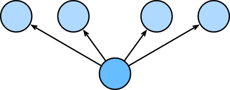

- $P(今,人,为,刀|方) = P(今|方)P(人|方)P(为|方)P(刀|方)$

CBOW

- 假设上下文生成中心词

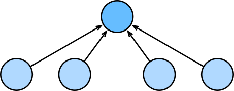

- $P(方|今,人,为,刀)$

两者训练流程相同，仅公式计算有区别

## 全局向量的词嵌入

[Pennington 2014] **全局向量的词嵌入 GloVe**：预先提取语料集的全局统计信息

- 以 $w_i$ 为中心词的上下文可能有多个
- **重数** $x_{ij}$ ：上下文中的词 $w_j$ 与 $w_i$ 共现的全局计数

（带全局语料统计的）skip-gram损失函数：$- \sum_{ij} x_{ij} \log P(w_j | w_i)$

GloVe损失函数：

$$\sum_{ij} h(x_{ij}) \left( w_j \cdot w_i + b_i + c_j - \log x_{ij} \right)^2$$

- 平方损失
- 中心词偏置 $b_i$ 和上下文词偏置 $c_i$
- 权重函数 $h(x_{ij})$：$h(x)$ 在$[0,1]$递增

## fastText模型

[Bojanowski 2017] fastText模型是一种**子词嵌入**方法

- 子词是基于单字符的N元语法
  - 可以被认为是子词级skip-gram

例如单词“where”

```
“<wh”、“whe”、“her”、“ere”、“re>”、“<where>”
```

开源：https://fasttext.cc

- 解决测试集中未知词`<unk>`的问题
- 解决词变形很多、在文本中罕见的问题

# 词嵌入的语义属性

## 上下文窗口

窗口大小决定上下文词汇，进而决定语言模型的**词汇分布**

- 小窗口$C=\pm 2$：在同一类别中，**语义相近、词类相同**的词
  - “刘备”：“关羽”、“诸葛亮”
  - [Levy 2014] Hogwarts: Sunnydale, Evernight
- 大窗口$C=\pm 5$：**主题相关，但语义并不相似**的词
  - “刘备”：“皇叔”、“蜀汉”
  - Hogwarts: Dumbledore, Malfoy, half-blood

## 两类关联关系

[Schütze 1993] 区别两类共生关系：关联度

- **一阶共生**：也称**横组合 syntagmatic 关联**，经常成对出现的词
  - 写：文章，作业
- **二阶共生**：也称**纵聚合 paradigmatic 关联**，有相似的共同邻居
  - 写：发表，批改

## 类比相似度

[Rumelhart 1973] **平行四边形 parallelogram 模型**：词义的类比

- 认知、发展心理学：**语言是词义理解的外在表现**，例如“费曼学习法”

```
apple:tree::grape:?
```

- 可用（向量）平行四边形法则找出目标词汇（的大概位置）

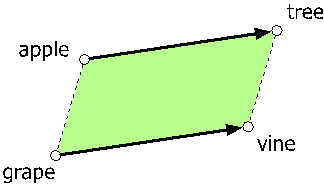

## 平行四边形法则

平行四边形法则可以用于**类比问题**

- [Turney 2005, Mikolov 2013] 对稀疏、稠密词嵌入都有效

```
王:男::后:？
中国:北京::法国:？
```

$a : b :: a' : b^*$问题的一般公式：求解优化问题

$$\hat{b}^* = \argmin_x \Delta(x, b-a+a')$$

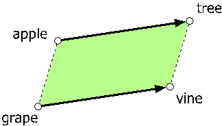

## 补充说明

$a : b :: a' : ?$：经常会返回输入的三个词，或它们的变形

- 解决方法：**词形还原**，并去除

通常对高频词比较有效，此外两种有效的特例：

- 向量间距离短：维数灾难导致**距离度量失效**
  - 维数还不能太低（否则不足以区分语义）
- 特殊类比：国家首都、词类明确

[Peterson 2020] 人类对类比的认知过程（因果推断）仍然是开放研究

## 应用：语义演化

[Hamilton 2016] 对不同时代的历史文档训练词嵌入

- ~30 million books, 1850-1990, Google Books data

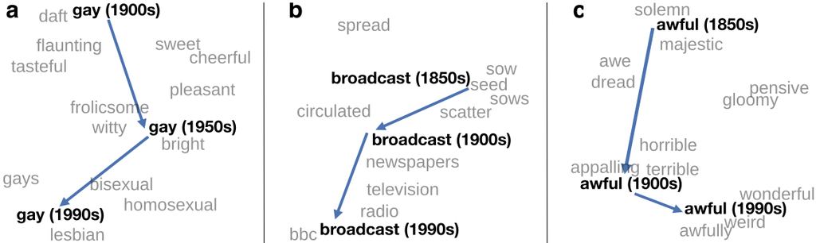

## 应用：偏见、歧视问题

[Bolukbasi 2016] 学到的词嵌入带有训练文本中的偏见

```
Q: 父亲:医生::母亲:？
A: 护士
```

[Crawford 2017, Blodgett 2020] **错配问题 allocational harm**

- 例如：招聘系统对性别的歧视性过滤，保险公司对人群的歧视性保费

[Zhao 2017, Jia 2020] 词嵌入会**强化偏见**

- 嵌入空间中相似的向量会聚合

## 历史、文化偏见

古代中国对外国人的观点：

```
俗无礼义，人性犷暴。形貌鄙陋，衣服毡褐。眼多碧绿，异于诸国。--《大唐西域记》
人皆高鼻深目，如回回状，身穿锁袱披裘，以皮为裤，又以皮囊其阴物，露出于外。头目常看书，取而视之,乃佛经也。--《静虚斋惜阴录》，明朝
```

[figure not shown]

近、现中国对外国人的观点：

```
为了把我自己打扮得像个西洋人……把自己装点成《老爷杂志》上的外国贵族模样……穿着最讲究的英国料子西服……手提“文明棍”，戴着德国蔡司厂出品的眼镜……身边还跟着两条或三条德国猎犬和奇装异服的一妻一妾。--《我的前半生》
“德先生”和“赛先生”，“民主”和“科学”--新文化运动
```

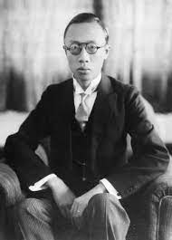

当代审美本质上是政治宣传：从“公知带路”到走出国门看真相

# Review

## 本章内容

**难点**：词嵌入表示的特点、优缺点。

## 问题

简述词嵌入表示的特点，及其优缺点。

简述 word2vec 的原理、skip-gram 的工作流程。

简述 CBOW、GloVe 静态嵌入算法

简述使用词嵌入做类比推断的原理，并举例说明几个语义分析应用。